# Power Analysis for replication

Kevin Potter

May 3, 2016

This is a record of a power analysis for a third replication attempt on the Wimber et al. (2015) study on cortical suppression as an explanation of retrieval induced forgetting.

First, we’ll fit three models to the original data kindly provided by Maria Wimber.

```r
str( datFit ) # Structure of data to be fitted
```

```
## 'data.frame':    3293 obs. of  6 variables:
##  $ Y       : num  1 1 1 1 0 1 1 1 1 1 ...
##  $ RIF_cond: Factor w/ 2 levels "0","1": 2 1 2 2 2 2 1 2 2 2 ...
##  $ S       : Factor w/ 24 levels "1","2","3","4",..: 1 1 1 1 1 1 1 1 1 1 ...
##  $ I       : Factor w/ 144 levels "1","2","3","4",..: 64 138 44 83 28 20 96 143 144 51 ...
##  $ IT      : Factor w/ 2 levels "1","2": 2 2 2 2 2 2 2 2 2 2 ...
##  $ SR      : Factor w/ 2 levels "0","1": 2 1 2 2 2 2 1 2 2 2 ...
```

```r
# Y is the accuracy ( 0 = wrong, 1 = right )
# I is an index for items
# S is an index for subjects
# RIF_cond is a factor indicating which trials were expected to have
#   a RIF effect (i.e. second associates shown in the selective retrieval
#   phase ).
# IT is a factor indicating the image type (first vs. second associates)
# SR is a factor indicating which images underwent selective retrieval
```

We’ll use a generalized linear model in which the data follows a bernoulli distribution, and for all models we’ll include random effects for subjects and items.

```r
# install.packages( 'lme4' )
library( lme4 )
RIF_model = glmer( Y ~ RIF_cond + (1|S) + (1|I), data = datFit,
                 family = binomial(link='logit'), weights = W )

Null_model = glmer( Y ~ (1|S) + (1|I), data = datFit,
                    family = binomial(link='logit'), weights = W )

AOV_model = glmer( Y ~ IT + SR + IT:SR + (1|S) + (1|I), data = datFit,
                   family = binomial(link='logit'), weights = W )
```

The AIC weights indicate that the RIF model is the best candidate of the three models, the most likely to fit a new sample of data.

```r
model_comparisons = anova( Null_model, RIF_model, AOV_model )

delta_AIC = model_comparisons$AIC - min( model_comparisons$AIC )
AIC_relative_likelihood = exp( -.5*delta_AIC )
AIC_weights = AIC_relative_likelihood / sum( AIC_relative_likelihood )
names( AIC_weights ) = c( 'Null', 'RIF', 'AOV' )

print( round( AIC_weights, 2 ) )
```

```
## Null  RIF  AOV
## 0.02 0.81 0.16
```

Examining the coefficients, the RIF model suggests that there is a drop of about 4% in the performance in recognition memory predicted in the population.

```r
RIF_results = summary( RIF_model )
round( RIF_results$coefficients[2,], 3 )
```

```
##   Estimate Std. Error    z value   Pr(>|z|)
##     -0.290      0.094     -3.089      0.002
```

```r
# Convert to percentage
Intercept = RIF_results$coefficients[1,1]
RIF = RIF_results$coefficients[2,1]
print( round( 100*( logit( Intercept ) - logit( Intercept + RIF ) ), 2 ) )
```

```
## [1] 4.08
```

We’ll use that as our upper bound for the power analyses, since effect sizes are typically over-estimated since the literature only publishes significant findings. We’ll test results for 4% to 0% in approximately 1% increments.

```r
# Loop through some possible combinations
RIF_effect = seq( -.29, 0, length = 5 )
Samp_size = c( 24, 48, 72 )
```

Simulating data using the RIF model and refitting the model to the simulations generates the following power-curves for sample sizes of 24, 48, and 72 subjects:

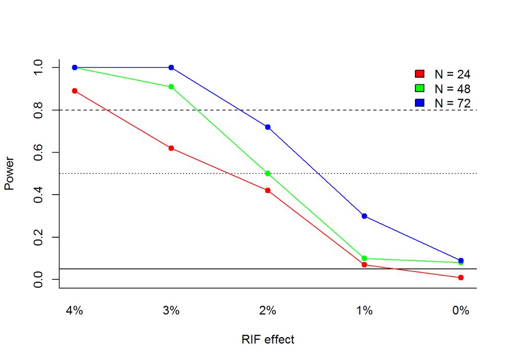

Note that the predicted power can vary between approximately +/- 5% since I only use 100 repetitions.